# Pharma and Biotech

### Receive grade

To Pass 80% or higher

### Your grade

100%

We keep your highest score

# Pharma and Biotech

### 1.

Question 1

According to the videos, in what direction is the pharmaceutical and biotechnology industry headed?

1 / 1 point

Better and more powerful drugs.

Innovation and cost reduction.

Equity and Equality.

Efficiency.

Correct

### 2.

Question 2

In terms of pharmaceutical developments, why has there been a shift to countries such as Asia?

1 / 1 point

A desire for cost reduction.

A desire for a larger market.

A desire for increased STEM (Science, Technology, Engineering, and Mathematics).

A desire for more employment.

Correct

### 3.

Question 3

Please observe the following graph:

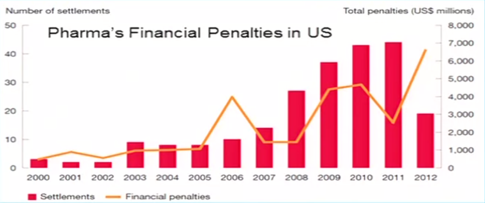

As mentioned in the lectures, what is the main cause of the apparent rise in financial penalties in the U.S.?

1 / 1 point

Escalating demands for medicine.

Strengthening scientific base.

Tight regulations.

Patent Cliffs.

Correct

### 4.

Question 4

Which of the following are opportunities for the pharma market? (Choose 3)

1 / 1 point

Wireless Health.

Correct

Trade liberalization.

Correct

Stronger Price controls.

Healthcare reduction costs.

Strengthening Scientific base.

Correct

### 5.

Question 5

According to the videos, who or what determines Pharma and Biotech innovation?

1 / 1 point

The cost of the drug

The customers

The advancement of the field

The investors

Correct

### 6.

Question 6

According to the videos, what is the ultimate future or direction of the Pharma company?

1 / 1 point

Biomarkers.

Repurposing of drugs.

Ultimate personalized medicine.

Diversity of drugs.

Correct

### 7.

Question 7

What type of product distribution model leads to siloed markets?

1 / 1 point

Blockbuster model

Customer centered model

Specialist model

Business model

Correct

### 8.

Question 8

What are the characteristics of the blockbuster model? (Choose 2)

1 / 1 point

Pricing - Depends on the market

Correct

R&D - Nimble decision-making process

Pricing - Pay for performance

R&D - Silos

Correct

### 9.

Question 9

According to the videos, what is disruptive innovation in pharma?

1 / 1 point

Cure a disease or prevent it.

Improve the quality of life.

Superiority in comparative trials.

Reduce the cost of care.

Correct

### 10.

Question 10

Payers are not going to pay a premium unless… (Choose 2)

1 / 1 point

Pharma race to develop new products, which all have the same mode of action.

Drug shows disruptive innovation.

Correct

Reduce the cost of care.

Be better than other drugs in trials and be cost efficient.

Correct

Improve the quality of life.

### 11.

Question 11

What makes specialty drugs less costly to develop compared to most prevalent diseases?

1 / 1 point

Clinical trials are smaller, only 100-200 subjects compared to several thousand

Correct

| Lower standard for scientific evidence required for orphan drugs |  |
| --- | --- |

Expedited reviews by the FDA and tax breaks

Correct

Seven years of competition-free marketing for new orphan drugs

Correct